# 統計4

Tomoki Motegi

2024-09-28

## 多変量解析

またデータはirisデータセットに戻る。ここからはアドバンスのため、余力がある人やこれらの統計が必要になった人だけ行う形で問題ない。

```r
## Rに収載されているデータ"iris"を呼び出して"iris_data"に格納
## なお、以降このデータを使うため、一度Rstudioを閉じた場合は一番最初から順々に動かして、各データを取ると良い。
iris_data = iris
## 最初の6行のみを表示
head(iris_data)
```

```
##   Sepal.Length Sepal.Width Petal.Length Petal.Width Species
## 1          5.1         3.5          1.4         0.2  setosa
## 2          4.9         3.0          1.4         0.2  setosa
## 3          4.7         3.2          1.3         0.2  setosa
## 4          4.6         3.1          1.5         0.2  setosa
## 5          5.0         3.6          1.4         0.2  setosa
## 6          5.4         3.9          1.7         0.4  setosa
```

```r
## setosa, versicolor, virginicaの各グループごとに分けたデータを作成
iris_sub_set = subset(x = iris_data, subset = iris_data$Species == "setosa")
iris_sub_ver = subset(x = iris_data, subset = iris_data$Species == "versicolor")
iris_sub_vir = subset(x = iris_data, subset = iris_data$Species == "virginica")
```

### ロジスティック回帰

本書を見た場合、なぜ線形回帰分析で重回帰分析を紹介しないのかと思うかもしれない。しかし中でも書いたようにロジスティック回帰の本質は線形回帰であり、そのパラメータを変えるだけで実施可能である。また単純な線形回帰よりも拡張された一般化線形モデルのほうが様々な分布を扱えるため、本稿ではロジスティック回帰を用いて学習していく。

| 分布名 | family(デフォルトのリンク関数) |
| --- | --- |
| 二項分布 | binomial(link = “logit”) |
| 正規分布（ガウス分布） | gaussian(link = “identity”) |
| ガンマ分布 | Gamma(link = “inverse”) |
| 逆ガウス分布（ワルド分布） | inverse.gaussian(link = “1/mu^2”) |
| ポアソン分布 | poisson(link = “log”) |
| 疑似尤度 | quasi(link = “identity”, variance = “constant”) |
| 疑似二項分布 | quasibinomial(link = “logit”) |
| 疑似ポアソン分布 | quasipoisson(link = “log”) |

#### ロジスティック単回帰

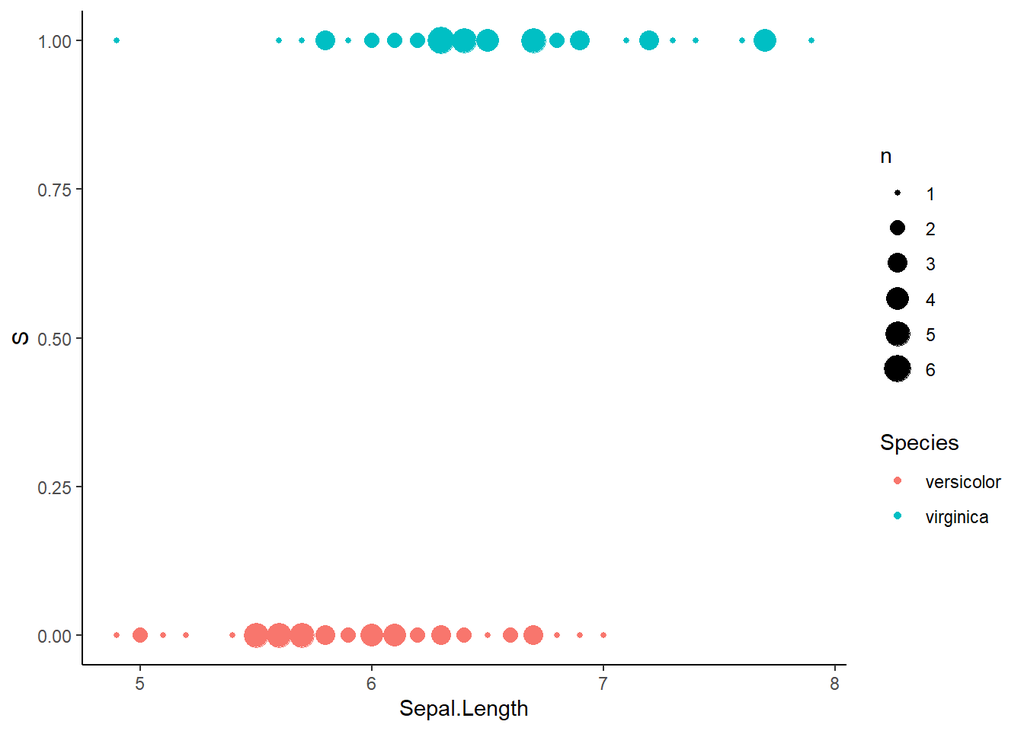

```r
## 2品種のデータを結合
ver_vir_data = rbind(iris_sub_ver, iris_sub_vir)
# versicolorを0、virginicaを1というダミー数字を割り当てた列Sを作成
ver_vir_data$S = c(rep(0, 50),rep(1,50))

## この分布を描画
library(ggplot2)
logit_ver_vir_gg = ggplot(data = ver_vir_data,
                       aes(x = Sepal.Length, y = S)) +
  geom_count(aes(color = Species)) +
  theme_classic()
logit_ver_vir_gg
```

続いてロジスティック回帰を行ってみる。ロジスティック回帰は一般化線形モデルを実行できるglm関数を用いて行う。

```r
## ロジスティック単回帰を実施
## versicolorかvirginica（つまり0か1か）をがくの長さ（Sepal.Length）から求める確率を算出する
logit_ver_vir = glm(S ~ Petal.Width, family = binomial(link = "logit"),
                    data = ver_vir_data)
summary(logit_ver_vir)
```

```
##
## Call:
## glm(formula = S ~ Petal.Width, family = binomial(link = "logit"),
##     data = ver_vir_data)
##
## Deviance Residuals:
##      Min        1Q    Median        3Q       Max
## -2.13868  -0.16468  -0.00929   0.13000   2.46891
##
## Coefficients:
##             Estimate Std. Error z value Pr(>|z|)
## (Intercept)  -21.126      4.597  -4.596 4.31e-06 ***
## Petal.Width   12.947      2.843   4.554 5.25e-06 ***
## ---
## Signif. codes:  0 '***' 0.001 '**' 0.01 '*' 0.05 '.' 0.1 ' ' 1
##
## (Dispersion parameter for binomial family taken to be 1)
##
##     Null deviance: 138.629  on 99  degrees of freedom
## Residual deviance:  33.421  on 98  degrees of freedom
## AIC: 37.421
##
## Number of Fisher Scoring iterations: 7
```

```r
confint(logit_ver_vir)
```

```
##                  2.5 %    97.5 %
## (Intercept) -32.144431 -13.68017
## Petal.Width   8.355608  19.79404
```

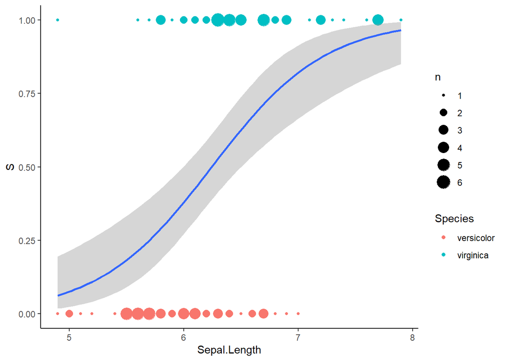

```r
## 上で書いた図にgeom_smooth関数を使ってglmを実施した結果で線を引いている
logit_ver_vir_gg = ggplot(data = ver_vir_data,
                       aes(x = Sepal.Length, y = S)) +
  geom_count(aes(color = Species)) +
  geom_smooth(method = "glm",
              method.args = list(family = binomial(link = "logit"))) +
  theme_classic()
logit_ver_vir_gg
```

#### ロジスティック重回帰

単回帰の結果では有意なものの、お互いをきれいに分類することは難しい。では「がくの長さと幅からアヤメの三品種（setosaとversicolorとvirginica）を分類」してみる。まずがくの長さと幅の関係を表してみる。

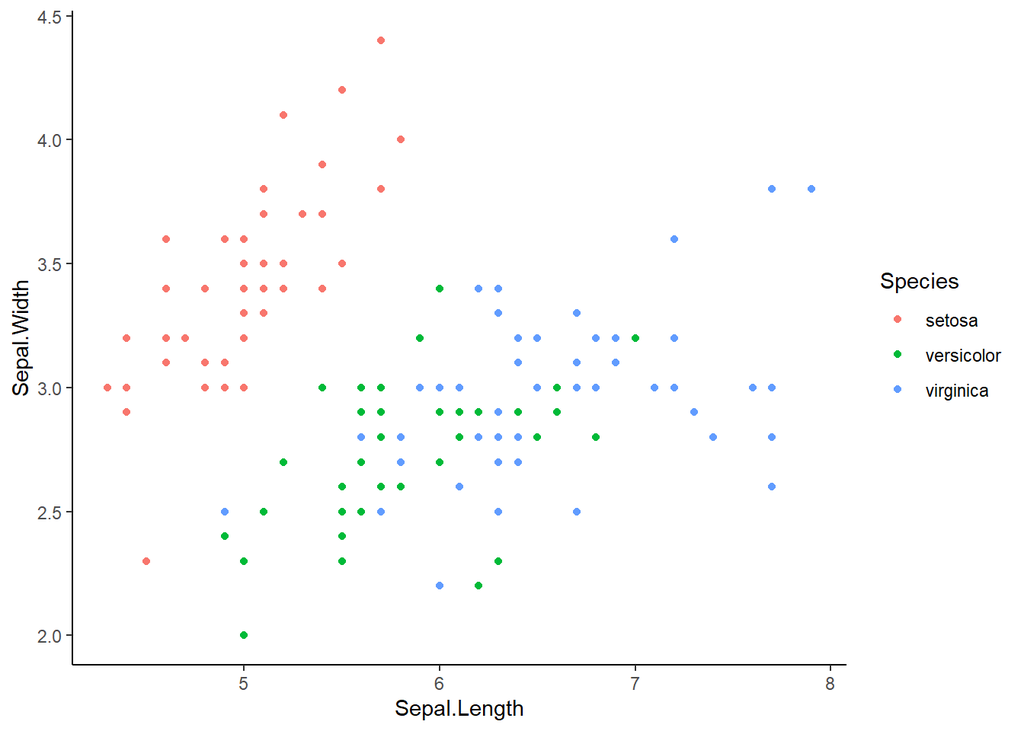

```r
iris_PL_PW_gg = ggplot(data = iris_data,
                       aes(x = Sepal.Length, y = Sepal.Width)) +
  geom_point(aes(color = Species)) +
  theme_classic()
iris_PL_PW_gg
```

ではこれを識別する多項ロジスティック回帰を行っていく。アヤメの三品種（setosaとversicolorとvirginica）を３つの組み合わせで0と1に分類してglmを行っても良いが、書籍のスペースに限りがあり、コードも冗長になるため、nnetパッケージのmultinom関数を用いて解析していく。

```r
## nnetパッケージの呼び出し
library(nnet)
## 多項ロジスティック回帰を行っている
## 多項分布専用のため、family の指定はない
iris_PL_PW_multi = multinom(Species ~ Sepal.Length + Sepal.Width, data = iris_data)
## 結果の確認
summary(iris_PL_PW_multi)
```

```
## Call:
## multinom(formula = Species ~ Sepal.Length + Sepal.Width, data = iris_data)
##
## Coefficients:
##            (Intercept) Sepal.Length Sepal.Width
## versicolor   -92.09924     40.40326   -40.58755
## virginica   -105.10096     42.30094   -40.18799
##
## Std. Errors:
##            (Intercept) Sepal.Length Sepal.Width
## versicolor    26.27831     9.142717    27.77772
## virginica     26.37025     9.131119    27.78875
##
## Residual Deviance: 110.425
## AIC: 122.425
```

```r
# モデルの係数に対する有意性のテスト (z値の計算)
z_values <- summary(iris_PL_PW_multi)$coefficients / summary(iris_PL_PW_multi)$standard.errors
p_values <- 2 * (1 - pnorm(abs(z_values)))

# z値とp値の表示
print("Z-values:")
```

```
## [1] "Z-values:"
```

```r
print(z_values)
```

```
##            (Intercept) Sepal.Length Sepal.Width
## versicolor   -3.504763     4.419175   -1.461155
## virginica    -3.985588     4.632613   -1.446197
```

```r
print("P-values:")
```

```
## [1] "P-values:"
```

```r
print(p_values)
```

```
##             (Intercept) Sepal.Length Sepal.Width
## versicolor 4.570135e-04  9.90786e-06    0.143973
## virginica  6.731329e-05  3.61079e-06    0.148122
```

最終的な結果からがくの長さのP値は低いものの、がくの幅のP値は低くない。summaryの結果から、以下のように考える。  
1. **Coefficients（回帰係数）**  
**Sepal.Length**（がくの長さ）の係数：

- `versicolor` の係数は `40.40326` で、`Sepal.Length` が1単位増加すると、`versicolor` に分類される対数オッズが約40.4増加することを意味する。
- `virginica` の係数は `42.30094` で、同様に `Sepal.Length` の増加が `virginica` に分類されるオッズを高めることを示している

**Sepal.Width**（がくの幅）の係数：

- `versicolor` の係数は `-40.58755` で、`Sepal.Width` が1単位増加すると `versicolor` に分類される対数オッズが約40.59減少することを意味する。つまり、`Sepal.Width` が大きくなるほど `versicolor` に分類される可能性は低くなる。
- `virginica` の係数も同様に `-40.18799` で、`Sepal.Width` が大きくなると `virginica` に分類されるオッズも低くなる。

2. **Std. Errors（標準誤差）**

- `Sepal.Length` の標準誤差は、`versicolor` で約 `9.14`、`virginica` で約 `9.13`
- `Sepal.Width` の標準誤差は、`versicolor` で約 `27.78`、`virginica` で約 `27.79`

標準誤差の値が大きい（特に `Sepal.Width`）ため、この説明変数に対する回帰係数の信頼性がやや低いことがわかる。つまり、がくの幅が分類に与える影響は不確実性が高いことが示唆される。

### 階層的クラスタリング

ロジスティック回帰ではあらかじめ正解の情報を与えて実施していた。しかし世の中には事前に正解情報が分からない場合も多い。そこで階層的クラスタリングを用いてirisデータセットの各情報の類似度から分類を行ってみる。まず距離行列を作成し、その後各データ間の距離を求めている。

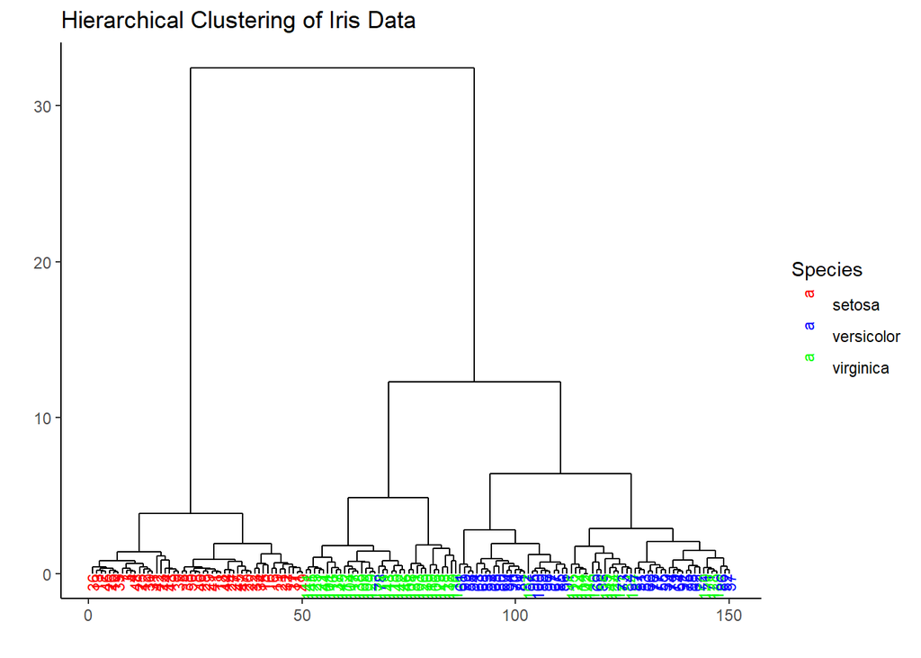

```r
## 品種情報を与えてしまうとそれで分類されてしまうため、がくと花びらの情報のみを使用する
## methodでユークリッド距離を与えている
iris_dist = dist(x = iris_data[, 1:4], method = "euclidean")

## 階層的クラスタリングを実施
## 今回はウォード法(ward.D2)を使用している
iris_hc = hclust(iris_dist, method = "ward.D2")

## 今回は視覚化しやすくするためにggplotのデンドログラム用パッケージを用いている
library(ggdendro)
iris_dd = dendro_data(as.dendrogram(iris_hc), type = "rectangle")

# クラスタリング結果のラベルを抽出し、元の品種と対応付ける
iris_dd$labels$Species = iris_data[as.numeric(iris_dd$labels$label), "Species"]

# 品種ごとに色を割り当ててデンドログラムを描画
iris_hc_gg = ggplot(data = segment(iris_dd)) +
  geom_segment(aes(x = x, y = y, xend = xend, yend = yend)) +
  geom_text(data = iris_dd$labels, aes(x = x, y = y, label = label, color = Species), hjust = 1, angle = 90, size = 3) +
  scale_color_manual(values = c("setosa" = "red", "versicolor" = "blue", "virginica" = "green")) +
  labs(title = "Hierarchical Clustering of Iris Data", x = "", y = "") +
  theme_classic()
iris_hc_gg
```

この結果を見ると教師なし学習でもsetosaは良く分類されており、一つで独立したクラスターを形成している。一方でversicolorとvirginicaもそこそこ分類されているが、やはり一部混ざってしまっており、がくと花びらの情報だけで分類することは難しいことがよくわかる。

### 主成分分析（Principal Component Analysis; PCA）

では続いてirisデータセットを主成分分析を用いて分類してみる。このままデータを使うとSepal.Lengthが最も大きく、それに引っ張られてしまうため標準化を行う。主成分分析を行うprcomp関数には標準化用のオプションがあるため、それを利用する。まずはデータの第一主成分（PC1）と第二主成分（PC2）を使って視覚化してみる。

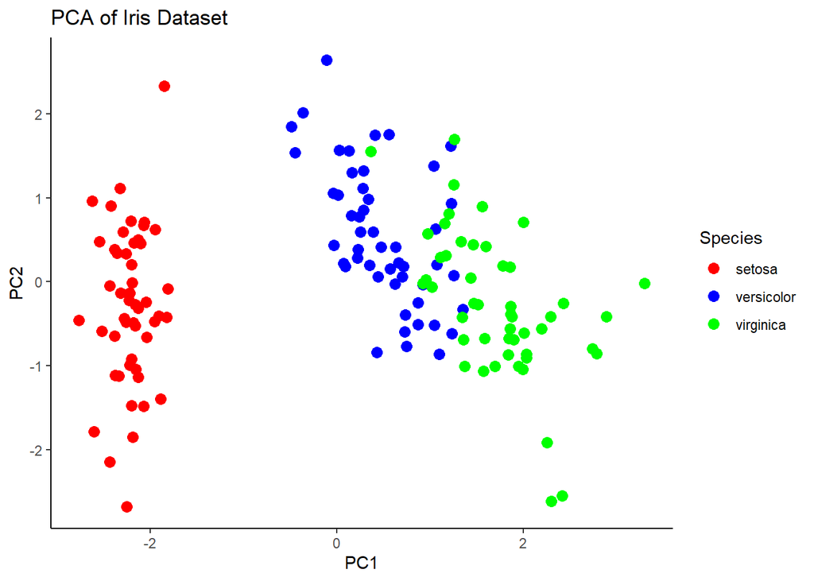

```r
## 主成分分析を実行
## center = TRUE, scale. = TRUEとすると標準化されて実行される
iris_pca = prcomp(x = iris_data[, 1:4], center = TRUE, scale. = TRUE)

# 主成分得点をデータフレームに変換し、元の品種情報を追加
iris_pca_data = data.frame(iris_pca$x, Species = iris_data$Species)

## ggplot2を使って主成分分析結果を可視化
iris_pca12_gg = ggplot(data = iris_pca_data,
                     aes(x = PC1, y = PC2, color = Species)) +
  geom_point(size = 3) +
  labs(title = "PCA of Iris Dataset", x = "PC1", y = "PC2") +
  scale_color_manual(values = c("setosa" = "red", "versicolor" = "blue", "virginica" = "green")) +
  theme_classic()

iris_pca12_gg
```

まだ分類が上手く行かないため、各主成分毎の寄与率を求めてみる。

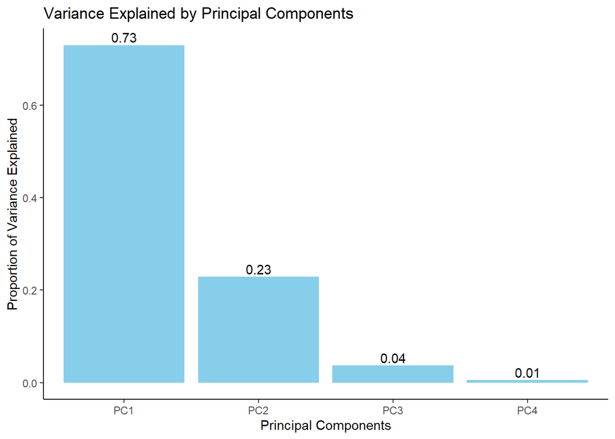

```r
## 主成分分析を実行
## center = TRUE, scale. = TRUEとすると標準化されて実行される
iris_pca = prcomp(x = iris_data[, 1:4], center = TRUE, scale. = TRUE)


## 各主成分の寄与率を計算
pca_variance = iris_pca$sdev^2  # 主成分ごとの分散
pca_variance_ratio = pca_variance / sum(pca_variance)  # 寄与率

## 寄与率をデータフレームに変換
pca_df = data.frame(Principal_Component = paste0("PC", 1:length(pca_variance_ratio)), Variance_Explained = pca_variance_ratio)

## 寄与率の棒グラフを描画
pca_df_gg = ggplot(data = pca_df,
                   aes(x = Principal_Component, y = Variance_Explained)) +
  geom_bar(stat = "identity", fill = "skyblue") +
  geom_text(aes(label = round(Variance_Explained, 2)), vjust = -0.3) +
  labs(title = "Variance Explained by Principal Components", x = "Principal Components", y = "Proportion of Variance Explained") +
  theme_classic()

pca_df_gg
```

この結果を見るとPC1で73%、PC2で23%説明を付けられるが、残り5%がPC3とPC4で説明されることがわかる。そこで試しにPC3との関係性を書いてみる。

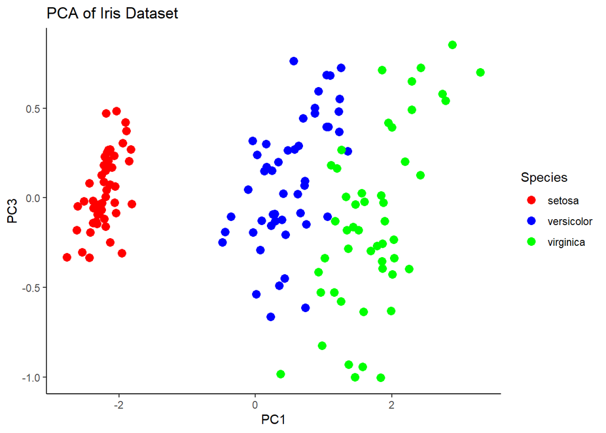

```r
## 主成分分析を実行
## center = TRUE, scale. = TRUEとすると標準化されて実行される
iris_pca = prcomp(x = iris_data[, 1:4], center = TRUE, scale. = TRUE)

# 主成分得点をデータフレームに変換し、元の品種情報を追加
iris_pca_data = data.frame(iris_pca$x, Species = iris_data$Species)

## ggplot2を使ってPC1とPC3を可視化
iris_pca13_gg = ggplot(data = iris_pca_data,
                     aes(x = PC1, y = PC3, color = Species)) +
  geom_point(size = 3) +
  labs(title = "PCA of Iris Dataset", x = "PC1", y = "PC3") +
  scale_color_manual(values = c("setosa" = "red", "versicolor" = "blue", "virginica" = "green")) +
  theme_classic()

iris_pca13_gg
```

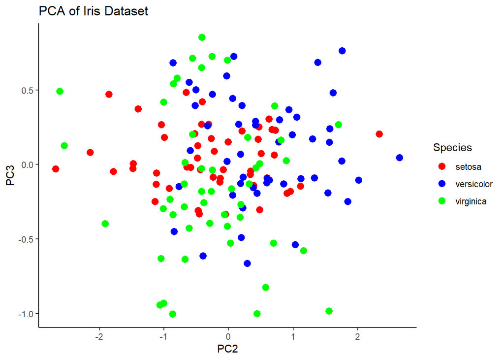

```r
## ggplot2を使ってPC2とPC3を可視化
iris_pca23_gg = ggplot(data = iris_pca_data,
                     aes(x = PC2, y = PC3, color = Species)) +
  geom_point(size = 3) +
  labs(title = "PCA of Iris Dataset", x = "PC2", y = "PC3") +
  scale_color_manual(values = c("setosa" = "red", "versicolor" = "blue", "virginica" = "green")) +
  theme_classic()

iris_pca23_gg
```

この結果を見ると意外なことにPC1とPC3の方がよく分かれているように見える。このためPC1-3までのデータを用いれば少なくとも重心は3群に分けることができるが、versicolorとvirginicaを完全に分けることは難しいということがわかる。

興味がある方は3次元空間で見た場合を試してみてほしい。

```r
##plotlyを使って三次元プロットを作成
library(plotly)
plot_ly(data = iris_pca_data, x = ~PC1, y = ~PC2, z = ~PC3, color = ~Species, colors = c("red", "blue", "green")) %>%
  add_markers() %>%
  layout(scene = list(xaxis = list(title = 'PC1'),
                      yaxis = list(title = 'PC2'),
                      zaxis = list(title = 'PC3')),
         title = "3D PCA of Iris Dataset")
```

[interactive chart not shown]

### Heatmap

引き続きirisデータセットで行ってみる。色々なパッケージがあるが拡張性が高いComplexheatmapパッケージを紹介する。

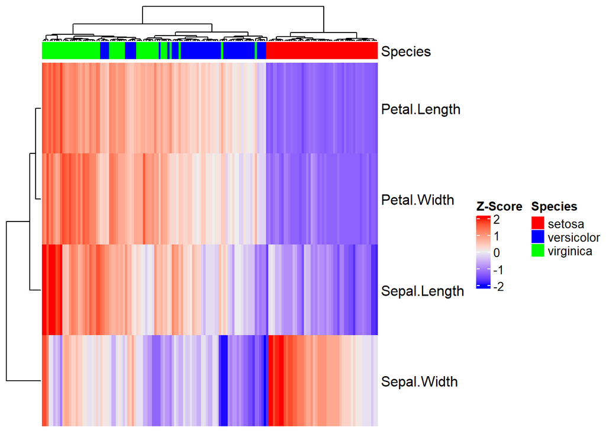

```r
## irisデータセットの数値データのみを抽出
## 数値データ: Sepal.Length, Sepal.Width, Petal.Length, Petal.Width
## Zスコア化（標準化）

iris_zscore <- as.data.frame(scale(iris_data[, 1:4]))
iris_zscore[iris_zscore < -2] = -2
iris_zscore[iris_zscore > 2] = 2

library(ComplexHeatmap)
library(circlize)
## 品種ごとの注釈データを作成
ann_colors = list(
  Species = c(setosa = "red", versicolor = "blue", virginica = "green"))
ha = HeatmapAnnotation(Species = iris_data$Species, col = ann_colors)

## ヒートマップを作成
ComplexHeatmap::Heatmap(as.matrix(t(iris_zscore)), name = "Z-Score",
                        top_annotation = ha,
                        show_row_names = TRUE,
                        clustering_distance_rows = "euclidean",
                        clustering_method_rows = "ward.D2",
                        show_column_names = TRUE,
                        clustering_distance_columns = "euclidean",
                        clustering_method_columns = "ward.D2",
                        column_names_gp = gpar(fontsize = 10),
                        cluster_rows = TRUE,  # 行クラスタリングを有効にする
                        cluster_columns = TRUE)  # 列クラスタリングを有効にする
```